# Reproducible Research. Project 2

Nadia Stavisky

7/28/2019

### The weather events analysis of impact on US population health and economic.

## Introduction

Storms and other severe weather events can cause both public health and economic problems for communities and municipalities. Many severe events can result in fatalities, injuries, and property damage, and preventing such outcomes to the extent possible is a key concern.

This project involves exploring the U.S. National Oceanic and Atmospheric Administration’s (NOAA) storm database. This database tracks characteristics of major storms and weather events in the United States, including when and where they occur, as well as estimates of any fatalities, injuries, and property damage.

The events in the database start in the year 1950 and end in November 2011. In the earlier years of the database there are generally fewer events recorded, most likely due to a lack of good records. More recent years should be considered more complete.

## Data Processing

The Data for this analysis loaded from [Storm Data](https://d396qusza40orc.cloudfront.net/repdata%2Fdata%2FStormData.csv.bz2)

```r
# loading data using the link, reading data into 'data' - R
# object:
datapath <- "https://d396qusza40orc.cloudfront.net/repdata%2Fdata%2FStormData.csv.bz2"
download.file(datapath, destfile = "./StormData.csv.bz2")
data <- read.csv2("StormData.csv.bz2", header = TRUE, sep = ",")
```

data dimensions and structure:

```r
dim(data)
```

```
## [1] 902297     37
```

```r
str(data)
```

```
## 'data.frame':    902297 obs. of  37 variables:
##  $ STATE__   : Factor w/ 70 levels "1.00","10.00",..: 1 1 1 1 1 1 1 1 1 1 ...
##  $ BGN_DATE  : Factor w/ 16335 levels "1/1/1966 0:00:00",..: 6523 6523 4242 11116 2224 2224 2260 383 3980 3980 ...
##  $ BGN_TIME  : Factor w/ 3608 levels "00:00:00 AM",..: 272 287 2705 1683 2584 3186 242 1683 3186 3186 ...
##  $ TIME_ZONE : Factor w/ 22 levels "ADT","AKS","AST",..: 7 7 7 7 7 7 7 7 7 7 ...
##  $ COUNTY    : Factor w/ 557 levels "0.00","1.00",..: 555 208 423 546 307 507 547 29 31 423 ...
##  $ COUNTYNAME: Factor w/ 29601 levels "","5NM E OF MACKINAC BRIDGE TO PRESQUE ISLE LT MI",..: 13513 1873 4598 10592 4372 10094 1973 23873 24418 4598 ...
##  $ STATE     : Factor w/ 72 levels "AK","AL","AM",..: 2 2 2 2 2 2 2 2 2 2 ...
##  $ EVTYPE    : Factor w/ 985 levels "   HIGH SURF ADVISORY",..: 834 834 834 834 834 834 834 834 834 834 ...
##  $ BGN_RANGE : Factor w/ 272 levels "0.00","0.10",..: 1 1 1 1 1 1 1 1 1 1 ...
##  $ BGN_AZI   : Factor w/ 35 levels "","  N"," NW",..: 1 1 1 1 1 1 1 1 1 1 ...
##  $ BGN_LOCATI: Factor w/ 54429 levels ""," Christiansburg",..: 1 1 1 1 1 1 1 1 1 1 ...
##  $ END_DATE  : Factor w/ 6663 levels "","1/1/1993 0:00:00",..: 1 1 1 1 1 1 1 1 1 1 ...
##  $ END_TIME  : Factor w/ 3647 levels ""," 0900CST",..: 1 1 1 1 1 1 1 1 1 1 ...
##  $ COUNTY_END: Factor w/ 1 level "0.00": 1 1 1 1 1 1 1 1 1 1 ...
```

[output cut: 23 more lines]

```r
summary(data)
```

[output not shown]

[output cut: 49 more lines]

[output not shown]

Subsetting data, selecting columns that are contain information: 1. EVTYPE - event type (factor); 2. FATALITIES - number of recorded fatalities; 3. INJURIES - number of recorded injuries; 4. PROPDMG - Property damage estimates; 5. PROPDMGEXP - magnitude of PROPDMG ( “K” for thousands, “M” for millions, and “B” for billions etc.); 6. CROPDMG - crop damage estimates; 7. CROPDMGEXP - magnitude of CROPDMG ( “K” for thousands, “M” for millions, and “B” for billions etc.);

```r
subsetdata <- data[, c("BGN_DATE", "REFNUM", "EVTYPE", "FATALITIES",
    "INJURIES", "PROPDMG", "PROPDMGEXP", "CROPDMG", "CROPDMGEXP")]
```

working dataset:

```r
data1 <- subsetdata
```

```r
head(data1)
```

```
##             BGN_DATE REFNUM  EVTYPE FATALITIES INJURIES PROPDMG PROPDMGEXP
## 1  4/18/1950 0:00:00   1.00 TORNADO       0.00    15.00   25.00          K
## 2  4/18/1950 0:00:00   2.00 TORNADO       0.00     0.00    2.50          K
## 3  2/20/1951 0:00:00   3.00 TORNADO       0.00     2.00   25.00          K
## 4   6/8/1951 0:00:00   4.00 TORNADO       0.00     2.00    2.50          K
## 5 11/15/1951 0:00:00   5.00 TORNADO       0.00     2.00    2.50          K
## 6 11/15/1951 0:00:00   6.00 TORNADO       0.00     6.00    2.50          K
##   CROPDMG CROPDMGEXP
## 1    0.00
## 2    0.00
## 3    0.00
## 4    0.00
## 5    0.00
## 6    0.00
```

Data transformation:

transform “FATALITIES”, “INJURIES”, “PROPDMG”, “CROPDMG” from factors in to numeric:

```r
numcol <- c("FATALITIES", "INJURIES", "PROPDMG", "CROPDMG")
data1[, numcol] <- mutate_if(data1[, numcol], is.factor, as.character)
data1[, numcol] <- sapply(data1[, numcol], as.numeric)
```

transform BGN_DATE from factors to dates

```r
data1$BGN_DATE <- mdy_hms(data1$BGN_DATE)
data1$BGN_DATE <- year(data1$BGN_DATE)
```

Standartize magnitude codes used in the dataset:

```r
levels(data1$PROPDMGEXP)
```

```
##  [1] ""  "-" "?" "+" "0" "1" "2" "3" "4" "5" "6" "7" "8" "B" "h" "H" "K"
## [18] "m" "M"
```

```r
levels(data1$CROPDMGEXP)
```

```
## [1] ""  "?" "0" "2" "B" "k" "K" "m" "M"
```

```r
# create df for PROPDMGEXP$CROPDMGEXP recoding:
DMGEXPlevels <- unique(as.character(c(levels(data1$PROPDMGEXP),
    levels(data1$CROPDMGEXP))))
DMGEXPint <- c(1, 1, 1, 1, 1, 1, 10^2, 10^3, 10^4, 10^5, 10^6,
    10^7, 10^8, 10^9, 10^2, 10^2, 10^3, 10^6, 10^6, 10^3)
PMGTDdf <- cbind(PROPDMGEXP = DMGEXPlevels, PDMGEXPint = DMGEXPint)
CMGTDdf <- cbind(CROPDMGEXP = DMGEXPlevels, CDMGEXPint = DMGEXPint)
```

```r
# create data set to use in visual analysis
data2 <- merge(data1, PMGTDdf, by = "PROPDMGEXP", all.x = TRUE)
data2 <- merge(data2, CMGTDdf, by = "CROPDMGEXP", all.x = TRUE)
data2$PROPDMGB <- (data2$PROPDMG * as.numeric(as.character(data2$PDMGEXPint)))/1e+09
data2$CROPDMGB <- (data2$CROPDMG * as.numeric(as.character(data2$CDMGEXPint)))/1e+09
data2$DMGEXPB <- data2$PROPDMGB + data2$CROPDMGB
data2$TTLHARM <- data2$FATALITIES + data2$INJURIES
```

```r
str(data2)
```

```
## 'data.frame':    902297 obs. of  15 variables:
##  $ CROPDMGEXP: Factor w/ 9 levels "","?","0","2",..: 1 1 1 1 1 1 1 1 1 1 ...
##  $ PROPDMGEXP: Factor w/ 19 levels "","-","?","+",..: 1 1 1 1 1 1 1 1 1 1 ...
##  $ BGN_DATE  : num  1991 1992 1959 1983 1990 ...
##  $ REFNUM    : Factor w/ 902297 levels "1.00","10.00",..: 21673 398857 12791 544647 409224 14389 884846 669969 325936 329757 ...
##  $ EVTYPE    : Factor w/ 985 levels "   HIGH SURF ADVISORY",..: 856 856 856 856 856 244 856 856 856 856 ...
##  $ FATALITIES: num  0 0 0 0 0 0 0 0 0 0 ...
##  $ INJURIES  : num  0 0 0 0 0 0 0 0 0 0 ...
##  $ PROPDMG   : num  0 0 0 0 0 0 0 0 0 0 ...
##  $ CROPDMG   : num  0 0 0 0 0 0 0 0 0 0 ...
##  $ PDMGEXPint: Factor w/ 9 levels "1","100","1000",..: 1 1 1 1 1 1 1 1 1 1 ...
##  $ CDMGEXPint: Factor w/ 9 levels "1","100","1000",..: 1 1 1 1 1 1 1 1 1 1 ...
##  $ PROPDMGB  : num  0 0 0 0 0 0 0 0 0 0 ...
##  $ CROPDMGB  : num  0 0 0 0 0 0 0 0 0 0 ...
##  $ DMGEXPB   : num  0 0 0 0 0 0 0 0 0 0 ...
##  $ TTLHARM   : num  0 0 0 0 0 0 0 0 0 0 ...
```

# Top weather events associated with greatest health harm.

Weather events grouped as: - Fatalities; - Injuries; - Fatalities + Injuries = Total Health Harm;

```r
healthplot <- data2 %>% subset(select = c(EVTYPE, FATALITIES,
    INJURIES, TTLHARM)) %>% gather(HealthDMGType, Value, c(FATALITIES,
    INJURIES, TTLHARM)) %>% group_by(HealthDMGType, EVTYPE) %>%
    summarize(sum_health_harm_K = sum(Value)/1000) %>% arrange(desc(sum_health_harm_K)) %>%
    group_by(HealthDMGType) %>% slice(1:10)
```

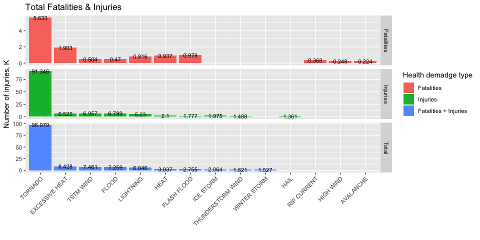

```r
healthplot$HealthDMGType <- factor(healthplot$HealthDMGType,
    levels = c("FATALITIES", "INJURIES", "TTLHARM"), labels = c("Fatalities",
        "Injuries", "Total"))
a <- ggplot(data = healthplot, aes(x = reorder(EVTYPE, -sum_health_harm_K,
    sum), y = sum_health_harm_K, fill = HealthDMGType))
a + geom_bar(stat = "identity") + facet_grid(HealthDMGType ~
    ., scales = "free") + geom_text(aes(label = sum_health_harm_K),
    size = 3) + theme(axis.text.x = element_text(angle = 45,
    hjust = 1)) + scale_fill_discrete(name = "Health demadge type",
    labels = c("Fatalities", "Injuries", "Fatalities + Injuries")) +
    labs(title = "Total Fatalities & Injuries", x = "", y = "Number of injuries, K")
```

#Summary. Top 5 weather events cused greatest health harm.

```r
healthplot %>% spread(HealthDMGType, sum_health_harm_K) %>% arrange(desc(Total)) %>%
    head(5)
```

```
## # A tibble: 5 x 4
##   EVTYPE         Fatalities Injuries Total
##   <fct>               <dbl>    <dbl> <dbl>
## 1 TORNADO             5.63     91.3  97.0
## 2 EXCESSIVE HEAT      1.90      6.52  8.43
## 3 TSTM WIND           0.504     6.96  7.46
## 4 FLOOD               0.47      6.79  7.26
## 5 LIGHTNING           0.816     5.23  6.05
```

# Top weather types of events with the greatest economic consequences.

Event types grouped by: - Property damadge; - Crop damadge; - Property damadge + Crop damadge = Total Economic Damadge.

```r
econplot <- data2 %>% subset(select = c(EVTYPE, PROPDMGB, CROPDMGB,
    DMGEXPB)) %>% gather(EconDMGType, Value, c(PROPDMGB, CROPDMGB,
    DMGEXPB)) %>% group_by(EconDMGType, EVTYPE) %>% summarize(sum_econ_harm_B = sum(Value)) %>%
    arrange(desc(sum_econ_harm_B)) %>% group_by(EconDMGType) %>%
    slice(1:10)
```

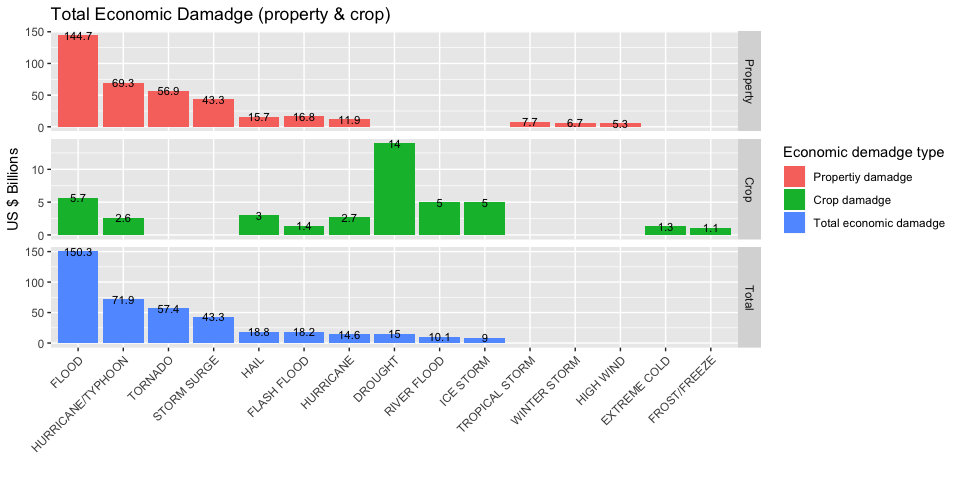

```r
econplot$EconDMGType <- factor(econplot$EconDMGType, levels = c("PROPDMGB",
    "CROPDMGB", "DMGEXPB"), labels = c("Property", "Crop", "Total"))
a <- ggplot(data = econplot, aes(x = reorder(EVTYPE, -sum_econ_harm_B,
    sum), y = sum_econ_harm_B, fill = EconDMGType))
a + geom_bar(stat = "identity") + facet_grid(EconDMGType ~ .,
    scales = "free") + geom_text(aes(label = round(sum_econ_harm_B,
    digits = 1)), size = 3) + theme(axis.text.x = element_text(angle = 45,
    hjust = 1)) + scale_fill_discrete(name = "Economic demadge type",
    labels = c("Propertiy damadge", "Crop damadge", "Total economic damadge")) +
    labs(title = "Total Economic Damadge (property & crop)",
        x = "", y = "US $ Billions")
```

#Summary. Top 5 weather events cused greatest economic harm.

```r
econplot %>% spread(EconDMGType, sum_econ_harm_B) %>% arrange(desc(Total)) %>%
    head(5)
```

```
## # A tibble: 5 x 4
##   EVTYPE            Property  Crop Total
##   <fct>                <dbl> <dbl> <dbl>
## 1 FLOOD                145.   5.66 150.
## 2 HURRICANE/TYPHOON     69.3  2.61  71.9
## 3 TORNADO               56.9 NA     57.4
## 4 STORM SURGE           43.3 NA     43.3
## 5 HAIL                  15.7  3.03  18.8
```